# DILI

#### Distribution of number of days of drug-free days over individuals

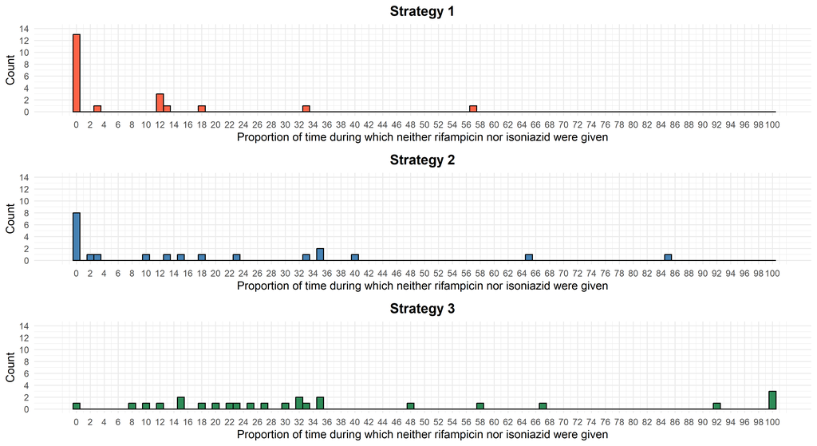

**Overall**

|  | Strategy 1: Observe N | Strategy 1: Observe Summary statistic (Median [1st, 3rd quartiles]) | Strategy 3: Stop RHZ N | Strategy 3: Stop RHZ Summary statistic (Median [1st, 3rd quartiles]) | Wilcoxon rank sum test p-value | Beta regression Difference |
| --- | --- | --- | --- | --- | --- | --- |
| percent of time during which neither rifampicin nor isoniazid were given | 21 | 0 (0, 11.67) | 25 | 30 (18.33, 48.33) | < 0.01 | 28.5 percent of time (15.9, 41.1); p = < 0.01 |

Percent of time = 100 * number of days during which neither rifampicin nor isoniazid were given / number of days patients alive

|  | Strategy 2: Stop Z N | Strategy 2: Stop Z Summary statistic (Median [1st, 3rd quartiles]) | Strategy 3: Stop RHZ N | Strategy 3: Stop RHZ Summary statistic (Median [1st, 3rd quartiles]) | Wilcoxon rank sum test p-value | Beta regression Difference |
| --- | --- | --- | --- | --- | --- | --- |
| percent of time during which neither rifampicin nor isoniazid were given | 21 | 10.2 (0, 33.33) | 25 | 30 (18.33, 48.33) | < 0.01 | 22.3 percent of time (8.3, 36.3); p = < 0.01 |

Percent of time = 100 * number of days during which neither rifampicin nor isoniazid were given / number of days patients alive

**With stratification by HIV Status**

|  | Strategy 1: Observe N | Strategy 1: Observe Summary statistic (Median [1st, 3rd quartiles]) | Strategy 3: Stop RHZ N | Strategy 3: Stop RHZ Summary statistic (Median [1st, 3rd quartiles]) | Wilcoxon rank sum test p-value | Beta regression Difference | Test for heterogeneity p-value |
| --- | --- | --- | --- | --- | --- | --- | --- |
| knowhiv |  |  |  |  |  |  | 0.46 |
| Positive | 9 | 0.00 (0.00, 11.67) | 13 | 31.67 (20.00, 66.67) | 0.012 | 30.2 percent of time (8.9, 51.5); p = < 0.01 |  |
| Negative | 12 | 0.00 (0.00, 11.69) | 12 | 28.33 (17.50, 35.07) | < 0.01 | 25.0 percent of time (14.2, 35.8); p = < 0.01 |  |

Test for heterogeneity is an Wald Test for interaction between treatment effect and each subgroup in the beta-regression model not including other variables.  
Percent of time = 100 * number of days during which neither rifampicin nor isoniazid were given / number of days patients alive

|  | Strategy 2: Stop Z N | Strategy 2: Stop Z Summary statistic (Median [1st, 3rd quartiles]) | Strategy 3: Stop RHZ N | Strategy 3: Stop RHZ Summary statistic (Median [1st, 3rd quartiles]) | Wilcoxon rank sum test p-value | Beta regression Difference | Test for heterogeneity p-value |
| --- | --- | --- | --- | --- | --- | --- | --- |
| knowhiv |  |  |  |  |  |  | 0.54 |
| Positive | 8 | 6.77 (0.00, 27.50) | 13 | 31.67 (20.00, 66.67) | 0.063 | 23.1 percent of time (-1.1, 47.2); p = 0.061 |  |
| Negative | 13 | 13.33 (0.00, 33.33) | 12 | 28.33 (17.50, 35.07) | 0.071 | 19.5 percent of time (6.1, 32.9); p = < 0.01 |  |

Test for heterogeneity is an Wald Test for interaction between treatment effect and each subgroup in the beta-regression model not including other variables.  
Percent of time = 100 * number of days during which neither rifampicin nor isoniazid were given / number of days patients alive

**With stratification by corticosteroids allocation**

|  | Strategy 1: Observe N | Strategy 1: Observe Summary statistic (Median [1st, 3rd quartiles]) | Strategy 3: Stop RHZ N | Strategy 3: Stop RHZ Summary statistic (Median [1st, 3rd quartiles]) | Wilcoxon rank sum test p-value | Beta regression Difference | Test for heterogeneity p-value |
| --- | --- | --- | --- | --- | --- | --- | --- |
| arm |  |  |  |  |  |  | 0.49 |
| Placebo | 9 | 0.00 (0.00, 3.33) | 12 | 19.17 (14.17, 26.25) | < 0.01 | 23.1 percent of time (8.2, 38.1); p = < 0.01 |  |
| Dexamethasone | 12 | 0.00 (0.00, 12.16) | 13 | 33.33 (30.00, 66.67) | < 0.01 | 33.8 percent of time (15.1, 52.4); p = < 0.01 |  |

Test for heterogeneity is an Wald Test for interaction between treatment effect and each subgroup in the beta-regression model not including other variables.  
Percent of time = 100 * number of days during which neither rifampicin nor isoniazid were given / number of days patients alive

|  | Strategy 2: Stop Z N | Strategy 2: Stop Z Summary statistic (Median [1st, 3rd quartiles]) | Strategy 3: Stop RHZ N | Strategy 3: Stop RHZ Summary statistic (Median [1st, 3rd quartiles]) | Wilcoxon rank sum test p-value | Beta regression Difference | Test for heterogeneity p-value |
| --- | --- | --- | --- | --- | --- | --- | --- |
| arm |  |  |  |  |  |  | 0.75 |
| Placebo | 13 | 0.00 (0.00, 15.00) | 12 | 19.17 (14.17, 26.25) | 0.014 | 20.8 percent of time (5.9, 35.6); p = < 0.01 |  |
| Dexamethasone | 8 | 26.67 (10.42, 46.25) | 13 | 33.33 (30.00, 66.67) | 0.31 | 17.7 percent of time (-6.7, 42.1); p = 0.16 |  |

Test for heterogeneity is an Wald Test for interaction between treatment effect and each subgroup in the beta-regression model not including other variables.  
Percent of time = 100 * number of days during which neither rifampicin nor isoniazid were given / number of days patients alive

**With time from primary randomisation to secondary DILI randomisation**

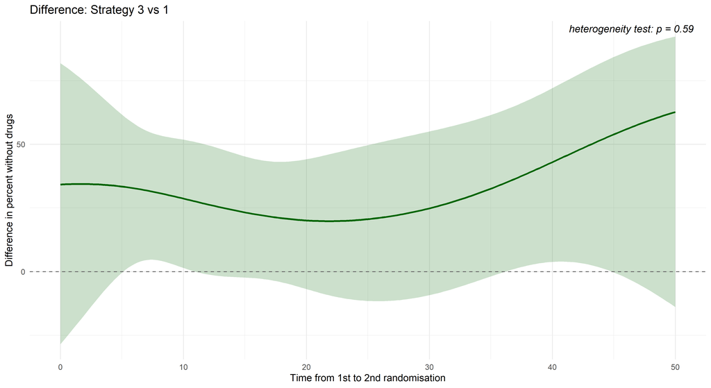

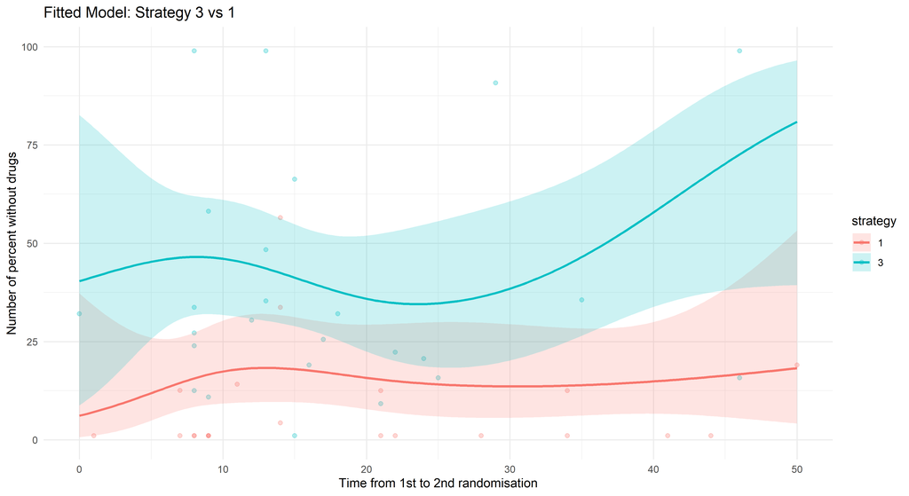

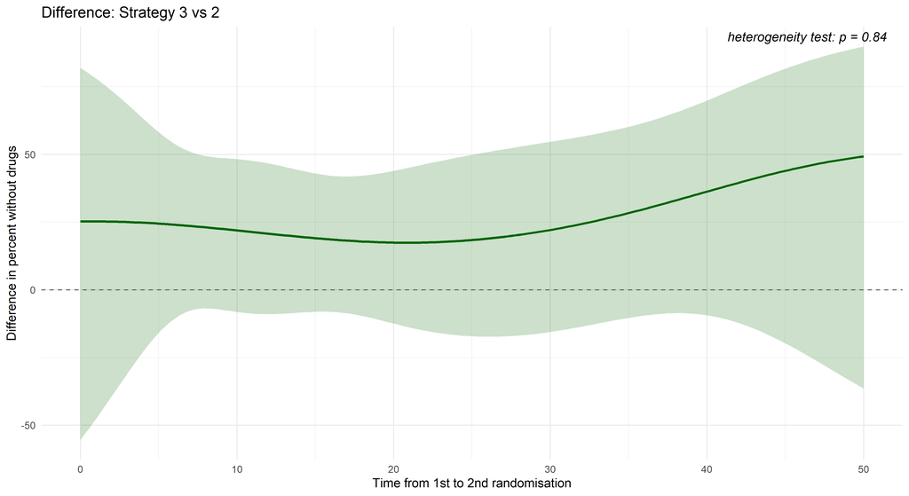

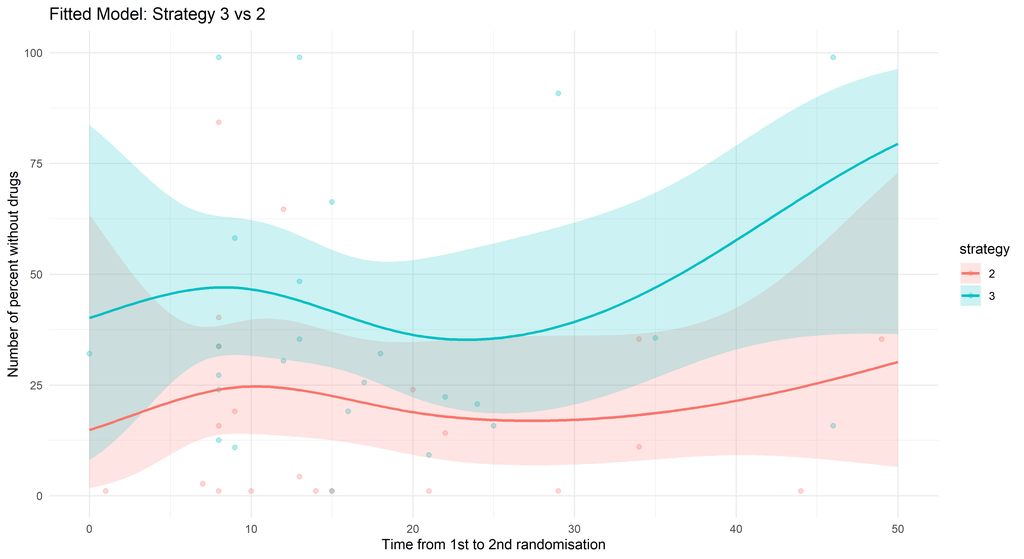

### 3.7 A comparison of The proportion of time in the 60 days following randomisation during which neither rifampicin nor isoniazid were given, between strategies 1 and 2

- Analysis similar to the primary outcome.

**Overall**

|  | Strategy 1: Observe N | Strategy 1: Observe Summary statistic (Median [1st, 3rd quartiles]) | Strategy 2: Stop Z N | Strategy 2: Stop Z Summary statistic (Median [1st, 3rd quartiles]) | Wilcoxon rank sum test p-value | Marginal effect Difference |
| --- | --- | --- | --- | --- | --- | --- |
| days during which neither rifampicin nor isoniazid were given | 21 | 7 (0, 31) | 21 | 9 (0, 21) | 0.76 | 0.3 days (-7.4, 7.9); p = 0.95 |

|  | Strategy 1: Observe N | Strategy 1: Observe Summary statistic (Median [1st, 3rd quartiles]) | Strategy 2: Stop Z N | Strategy 2: Stop Z Summary statistic (Median [1st, 3rd quartiles]) | Wilcoxon rank sum test p-value | Marginal effect Difference |
| --- | --- | --- | --- | --- | --- | --- |
| percent during which neither rifampicin nor isoniazid were given | 21 | 11.67 (0, 51.67) | 21 | 15 (0, 35) | 0.76 | 0.4 percent (-12.3, 13.1); p = 0.95 |

**With stratification by HIV Status**

|  | Strategy 1: Observe N | Strategy 1: Observe Summary statistic (Median [1st, 3rd quartiles]) | Strategy 2: Stop Z N | Strategy 2: Stop Z Summary statistic (Median [1st, 3rd quartiles]) | Wilcoxon rank sum test p-value | Beta regression Difference | Test for heterogeneity p-value |
| --- | --- | --- | --- | --- | --- | --- | --- |
| knowhiv |  |  |  |  |  |  | 0.78 |
| Positive | 9 | 0.00 (0.00, 20.00) | 8 | 5.50 (0.00, 21.75) | 0.68 | 1.4 days (-11.4, 14.2); p = 0.83 |  |
| Negative | 12 | 7.50 (0.00, 34.00) | 13 | 11.00 (0.00, 21.00) | 1.0 | -0.8 days (-10.1, 8.6); p = 0.87 |  |

Test for heterogeneity is an Wald Test for interaction between treatment effect and each subgroup in the beta-regression model not including other variables.

|  | Strategy 1: Observe N | Strategy 1: Observe Summary statistic (Median [1st, 3rd quartiles]) | Strategy 2: Stop Z N | Strategy 2: Stop Z Summary statistic (Median [1st, 3rd quartiles]) | Wilcoxon rank sum test p-value | Beta regression Difference | Test for heterogeneity p-value |
| --- | --- | --- | --- | --- | --- | --- | --- |
| knowhiv |  |  |  |  |  |  | 0.78 |
| Positive | 9 | 0.00 (0.00, 33.33) | 8 | 9.17 (0.00, 36.25) | 0.68 | 2.4 percent (-19.0, 23.7); p = 0.83 |  |
| Negative | 12 | 12.50 (0.00, 56.67) | 13 | 18.33 (0.00, 35.00) | 1.0 | -1.3 percent (-16.9, 14.3); p = 0.87 |  |

Test for heterogeneity is an Wald Test for interaction between treatment effect and each subgroup in the beta-regression model not including other variables.

**With stratification by corticosteroids allocation**

|  | Strategy 1: Observe N | Strategy 1: Observe Summary statistic (Median [1st, 3rd quartiles]) | Strategy 2: Stop Z N | Strategy 2: Stop Z Summary statistic (Median [1st, 3rd quartiles]) | Wilcoxon rank sum test p-value | Beta regression Difference | Test for heterogeneity p-value |
| --- | --- | --- | --- | --- | --- | --- | --- |
| arm |  |  |  |  |  |  | 0.21 |
| Placebo | 9 | 7.00 (0.00, 31.00) | 13 | 2.00 (0.00, 16.00) | 0.56 | -3.8 days (-14.4, 6.9); p = 0.49 |  |
| Dexamethasone | 12 | 3.50 (0.00, 23.50) | 8 | 16.00 (6.25, 27.75) | 0.21 | 6.4 days (-5.7, 18.5); p = 0.30 |  |

Test for heterogeneity is an Wald Test for interaction between treatment effect and each subgroup in the beta-regression model not including other variables.

|  | Strategy 1: Observe N | Strategy 1: Observe Summary statistic (Median [1st, 3rd quartiles]) | Strategy 2: Stop Z N | Strategy 2: Stop Z Summary statistic (Median [1st, 3rd quartiles]) | Wilcoxon rank sum test p-value | Beta regression Difference | Test for heterogeneity p-value |
| --- | --- | --- | --- | --- | --- | --- | --- |
| arm |  |  |  |  |  |  | 0.21 |
| Placebo | 9 | 11.67 (0.00, 51.67) | 13 | 3.33 (0.00, 26.67) | 0.56 | -6.3 percent (-24.1, 11.5); p = 0.49 |  |
| Dexamethasone | 12 | 5.83 (0.00, 39.17) | 8 | 26.67 (10.42, 46.25) | 0.21 | 10.7 percent (-9.5, 30.8); p = 0.30 |  |

Test for heterogeneity is an Wald Test for interaction between treatment effect and each subgroup in the beta-regression model not including other variables.

**With time from primary randomisation to secondary DILI randomisation**

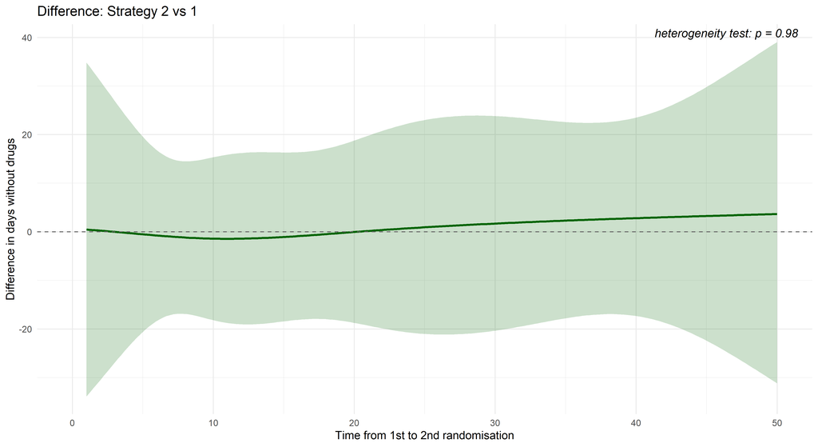

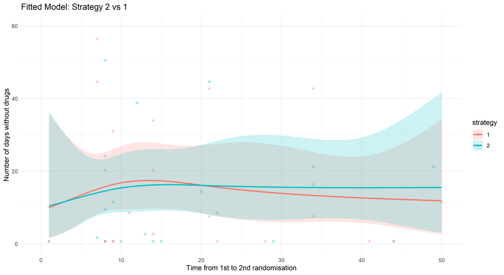

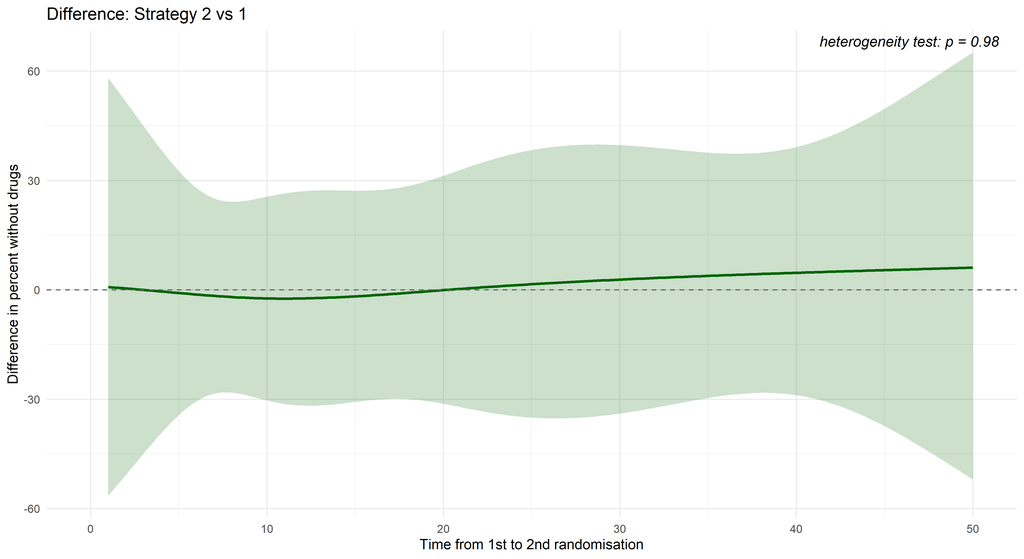

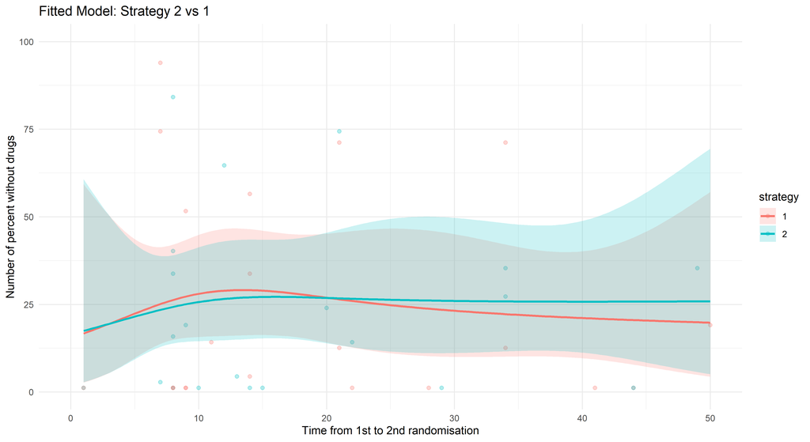

### 3.8 Longitudinal values of ALT and bilirubin from DILI randomisation onwards

For this analysis, we fitted a linear mixed-effects model for log-transformed ALT values that included time (days since randomisation) as a continuous variable modeled using a natural cubic spline with one internal knot at day 40 and boundary knots at days 0 and 80. The model included an interaction between the spline term for time and treatment strategy, allowing ALT trajectories to vary by strategy. Random intercepts and random slopes for time were included at the subject level to account for within-subject correlation.

**log transformed ALT trends comparision via a random effects model**

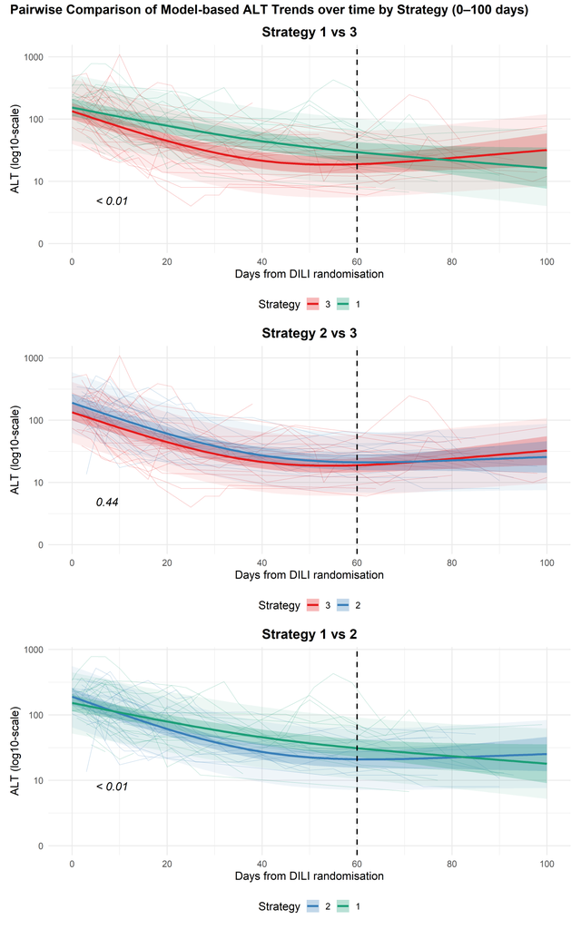

**log transformed Bilirubn trends comparision via a random effects model**

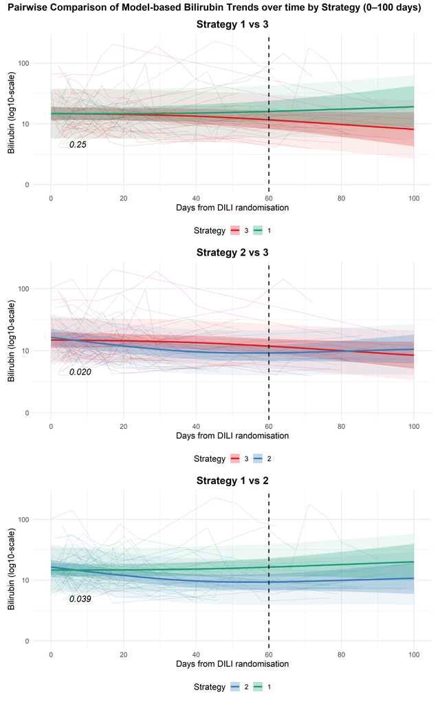

#### Peak values of ALT and Bilirubin

Peak values were summarized as medians with quartiles.

| Strategy | ALT Median | ALT Q1 | ALT Q3 | ALT Min | ALT Max | Bilirubin Median | Bilirubin Q1 | Bilirubin Q3 | Bilirubin Min | Bilirubin Max |
| --- | --- | --- | --- | --- | --- | --- | --- | --- | --- | --- |
| 1 | 226.9 | 143.0 | 328 | 5 | 780.0 | 22.6 | 14.8 | 53.6 | 2.9 | 229.2 |
| 2 | 242.0 | 154.8 | 288 | 8 | 517.0 | 19.2 | 12.9 | 47.4 | 2.0 | 146.9 |
| 3 | 213.0 | 118.2 | 309 | 4 | 1,097.9 | 22.8 | 14.4 | 48.2 | 3.1 | 203.9 |

### 3.9 Total drug doses (grams) in the first 60 days after DILI randomisation

| Characteristic | Overall N = 671 | Strategy 1: Observe N = 211 | Strategy 2: Stop Z N = 211 | Strategy 3: Stop RHZ N = 251 |
| --- | --- | --- | --- | --- |
| RIFAMPICIN | 19; 23 (10, 27) [N=67] | 21; 23 (16, 27) [N=21] | 21; 24 (11, 27) [N=21] | 16; 19 (2, 24) [N=25] |
| ISONIAZID | 11; 12 (6, 15) [N=67] | 11; 12 (7, 15) [N=21] | 13; 13 (9, 18) [N=21] | 9; 12 (3, 13) [N=25] |
| PYRAZINAMIDE | 15; 2 (0, 28) [N=67] | 32; 29 (13, 52) [N=21] | 6; 0 (0, 1) [N=21] | 9; 0 (0, 2) [N=25] |
| ETB | 45; 49 (27, 61) [N=67] | 39; 49 (20, 49) [N=21] | 51; 49 (41, 73) [N=21] | 45; 49 (28, 61) [N=25] |
| LEVOFLOXACINE | 24; 19 (11, 31) [N=43] | 15; 11 (3, 18) [N=8] | 37; 36 (19, 54) [N=10] | 22; 19 (10, 27) [N=25] |
| AMINOGLYCOSIDE | 23; 20 (9, 34) [N=43] | 21; 15 (8, 33) [N=11] | 27; 30 (13, 42) [N=12] | 21; 18 (10, 28) [N=20] |

1Summary statistic = the mean; median (1st and 3rd quartile) [N=number of participants contributing to that statistic.]  
Aminoglycoside represents streptomycin and kanamycin.

### Summary of the time from 1st randomisation to 2nd randomisation stratified by neurological event before DILI

| Summary of Time 1st to 2nd Randomisation Neurological event before DILI | Summary of Time 1st to 2nd Randomisation N | Summary of Time 1st to 2nd Randomisation Mean (SD) | Summary of Time 1st to 2nd Randomisation Median [IQR] |
| --- | --- | --- | --- |
| No | 49 | 18.55 (13.89) | 14 [8, 25] |
| Yes | 18 | 17.17 (8.77) | 15 [9, 21.8] |